# Assignment2

Abhishek kumar Gupta

March 23, 2019

# 1. The following will require a derivation and R functions:

## a. Write down Bayes’ theorem

## Baye’s theorem

$$p(A/B) = \frac {p(B/A)*p(A)}{p(B)}$$

## b. Derive the general posterior result for a Beta prior and Binomial likelihood. (Show all working)

Since X is a binomial distribution with $X\sim Bin(n,\theta)$, it can be written as:
$$p(x|\theta)={n\choose x}\theta^{x} (1-\theta)^{n-x}$$
Also, given is $\theta$ follows beta distribution as $\theta\sim Beta(\alpha,\beta)$

since,
$$p(\theta|\alpha,\beta) = beta (\theta|\alpha,\beta)$$

So we can expand the beta distribution as follows:
$$p(\theta|\alpha,\beta) = \frac{1}{B(\alpha,\beta)}\theta^{\alpha-1}(1-\theta)^{\beta-1}$$
SInce, by Bay’s reule we know that
$$posterior \propto prior* likelihood$$
So, we can write as:
$$p(\theta|x) \propto p(\theta)p(x|\theta)\\$$
and substituting the prior and likelihood function form the above equations, we get
$$p(\theta|x)\propto \frac{1}{B(\alpha,\beta)}\theta^{\alpha-1}(1-\theta)^{\beta-1}{n\choose x}\theta^{x} (1-\theta)^{n-x}$$
To remove he proprtional we, have a constant (called evidence in Bay’s rule), So we have now
$$p(\theta|x)= \frac{1}{B(\alpha,\beta)}\theta^{\alpha-1}(1-\theta)^{\beta-1}\frac{1}{p(x,n)}{n\choose x}\theta^{x} (1-\theta)^{n-x}$$
After re-arranging the trems, we get
$$p(\theta|x)= \theta^{\alpha-1}(1-\theta)^{\beta-1}{n\choose x}\theta^{x} (1-\theta)^{n-x} \frac{1}{[B(\alpha,\beta)*p(x,n)]}$$
By collecting powers of same trems, we get

$$p(\theta|x)= \theta^{\alpha+x-1}(1-\theta)^{\beta+n-x-1}{n\choose x} \frac{1}{[B(\alpha,\beta)*p(x,n)]}$$
Since ${n\choose x}$ is constant like the bottom terms, we can write together as a function of constant terms as:
$$p(\theta|x)= \theta^{(\alpha+x)-1}(1-\theta)^{(\beta+n-x)-1} \frac{1}{[B(\alpha+x,\beta+n-x)]}$$
rearranging the terms, we get the beta distribution as seen form below:

$$p(\theta|x)= \theta^{(x+ \alpha)-1}(1-\theta)^{(n-x+\beta)-1} \frac{1}{[B(x+\alpha,n-x+\beta)]}$$
Hence, we get
$$\theta|x \propto Beta(x+ \alpha, n-x+\beta)$$

## c. Plot the three graphs on one interface using R and use the experimental results n=10, x=4 with a uniform prior.

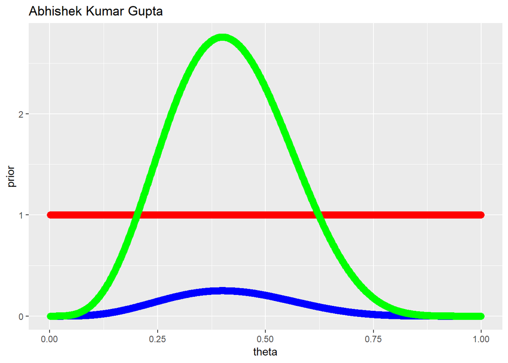

```r
library(ggplot2)
a=1
b=1
n=10
x=4
theta = seq(0.001,0.999,by=0.001) # points for plotting
prior= dbeta(theta,a,b)
post = dbeta( theta , a+x , b+n-x ) # posterior for plotting
lik= dbinom(x=x,size = n, theta) # likelihood for plotting
df = data.frame(theta, prior, lik, post)
myplot = ggplot(df, aes(theta)) + geom_point(aes(y=prior), col = "red", size = 3) +
  geom_point(aes(y=lik), col = "blue", size =3) +geom_point(aes(y=post), col ="green", size =3) +
  labs(title = "Abhishek Kumar Gupta")
myplot
```

## d. Make a function that will create a similar plot but for different alpha, beta, n and x. Call the function mybeta()

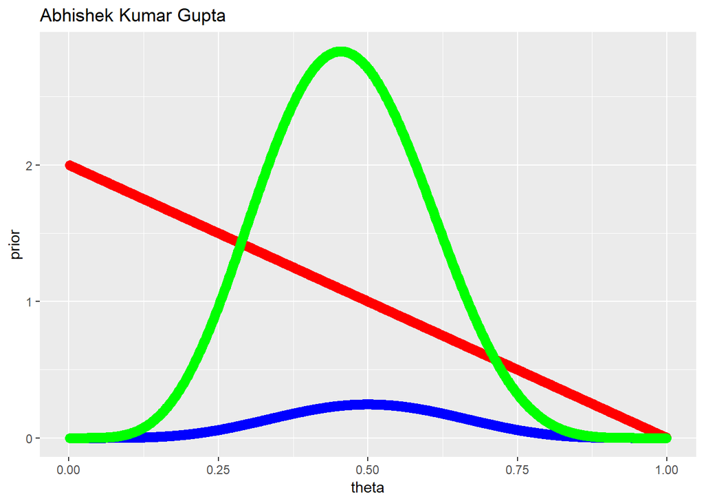

```r
mybeta = function(a,b,n,x)
{
  theta = seq(0.001,0.999,by=0.001) # points for plotting
  prior= dbeta(theta,a,b)
  post = dbeta( theta , x+a , n-x+b ) # posterior for plotting
  lik= dbinom(x=x,size = n, theta) # likelihood for plotting
  df = data.frame(theta, prior, lik, post)
  myplot = ggplot(df, aes(theta)) + geom_point(aes(y=prior), col = "red", size = 3) +
    geom_point(aes(y=lik), col = "blue", size =3) +geom_point(aes(y=post), col ="green", size =3) +
    labs(title = "Abhishek Kumar Gupta")
  return (myplot)
}

mybeta(1,2,10,5)
```

## e. Give the ouput of the function when the following is submitted:

### i. Mybeta(alpha = 2, beta=2, n=10, x=6)

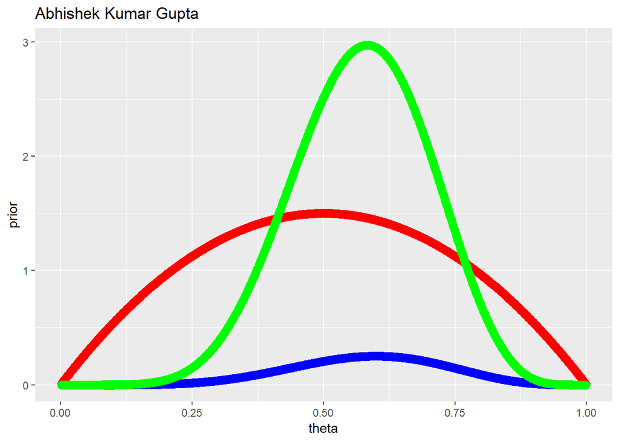

```r
mybeta(2,2,10,6)
```

### ii. Mybeta(alpha = 4, beta=2, n=10, x=6)

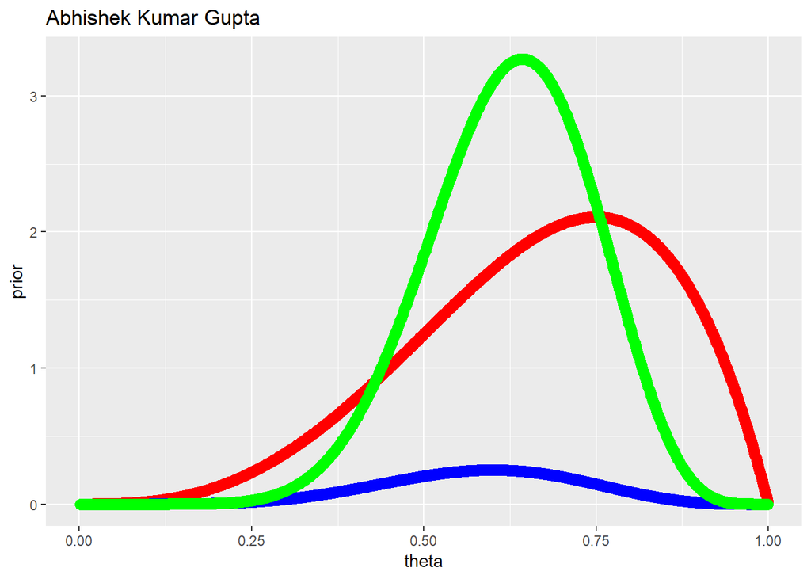

```r
mybeta(4,2,10,6)
```

### iii. Mybeta(alpha = 2, beta=4, n=10, x=6)

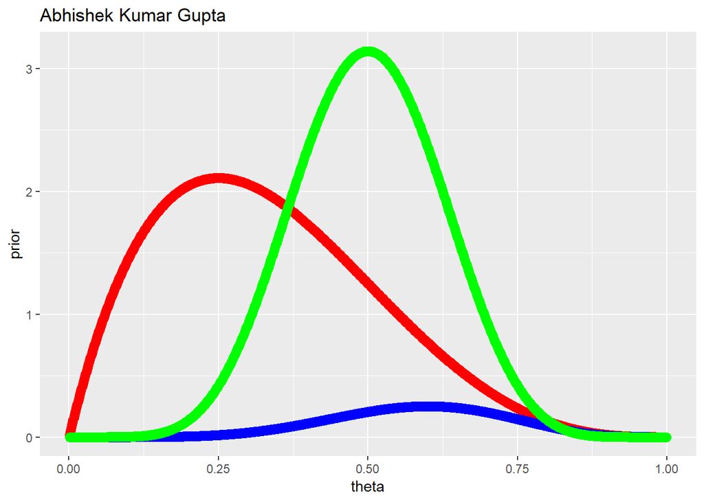

```r
mybeta(2,4,10,6)
```

### iv. Mybeta(alpha = 20, beta=20, n=10, x=6)

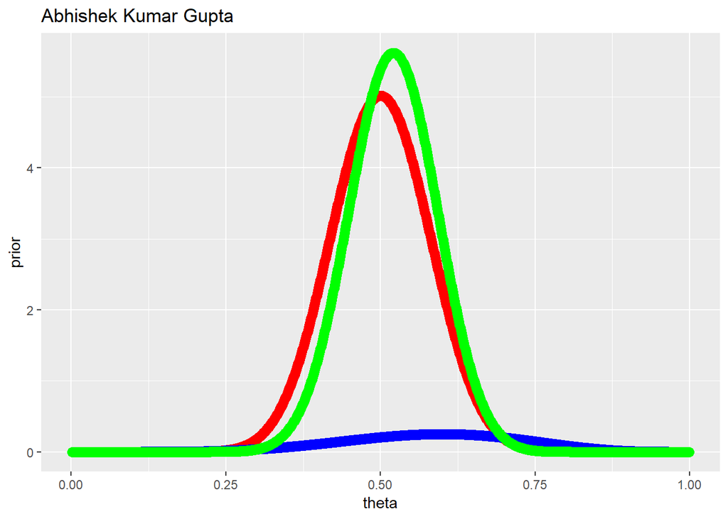

```r
mybeta(20,20,10,6)
```

## f. Now make a new function (mybeta2()) that will produce the same plots as mybeta() but will release command line Bayesian point estimates and BCI’s of whatever equal tail size we wish - all estimating “p”. The command line output will be a list containing these estimates (all appropriately labelled). Give the ouputs of:

```r
HDIofICDF = function( ICDFname , credMass=0.95 , tol=1e-8 , ... ) {
  # Arguments:
  #   ICDFname is R's name for the inverse cumulative density function
  #     of the distribution.
  #   credMass is the desired mass of the HDI region.
  #   tol is passed to R's optimize function.
  # Return value:
  #   Highest density iterval (HDI) limits in a vector.
  # Example of use: For determining HDI of a beta(30,12) distribution, type
  #   HDIofICDF( qbeta , shape1 = 30 , shape2 = 12 )
  #   Notice that the parameters of the ICDFname must be explicitly named;
  #   e.g., HDIofICDF( qbeta , 30 , 12 ) does not work.
  # Adapted and corrected from Greg Snow's TeachingDemos package.
  incredMass =  1.0 - credMass
  intervalWidth = function( lowTailPr , ICDFname , credMass , ... ) {
    ICDFname( credMass + lowTailPr , ... ) - ICDFname( lowTailPr , ... )
  }
  optInfo = optimize( intervalWidth , c( 0 , incredMass ) , ICDFname=ICDFname ,
                      credMass=credMass , tol=tol , ... )
  HDIlowTailPr = optInfo$minimum
  return( c( ICDFname( HDIlowTailPr , ... ) ,
             ICDFname( credMass + HDIlowTailPr , ... ) ) )
}

mybeta2 = function(a,b,n,x,alpha)
{
  library(ggplot2)
  theta = seq(0.001,0.999,by=0.001) # points for plotting
  prior= dbeta(theta,a,b)
  post = dbeta( theta , x+a , n-x+b ) # posterior for plotting
  lik= dbinom(x=x,size = n, theta) # likelihood for plotting
  df = data.frame(theta, prior, lik, post)
  myplot = ggplot(df, aes(theta)) + geom_point(aes(y=prior), col = "red", size = 5) +
    geom_point(aes(y=lik), col = "blue", size =3) +geom_point(aes(y=post), col ="green", size =3) +
    labs(title = "Abhishek Kumar Gupta")
  mean = a/(a+b)
  mode = (a-1)/(a+b-2)
  HDImass = 1-alpha
  HDIinfo = HDIofICDF( qbeta , shape1=a , shape2=b , credMass=HDImass )

  return (list(mean = mean, mode = mode,BCI = HDIinfo, myplot))
}
```

### i. Mybeta2(alpha = 2, beta=2, n=10, x=4, alphalevel=0.05

```r
mybeta2(2,2,10,4,0.05)
```

```
## $mean
## [1] 0.5
##
## $mode
## [1] 0.5
##
## $BCI
## [1] 0.09429932 0.90570068
##
## [[4]]
```

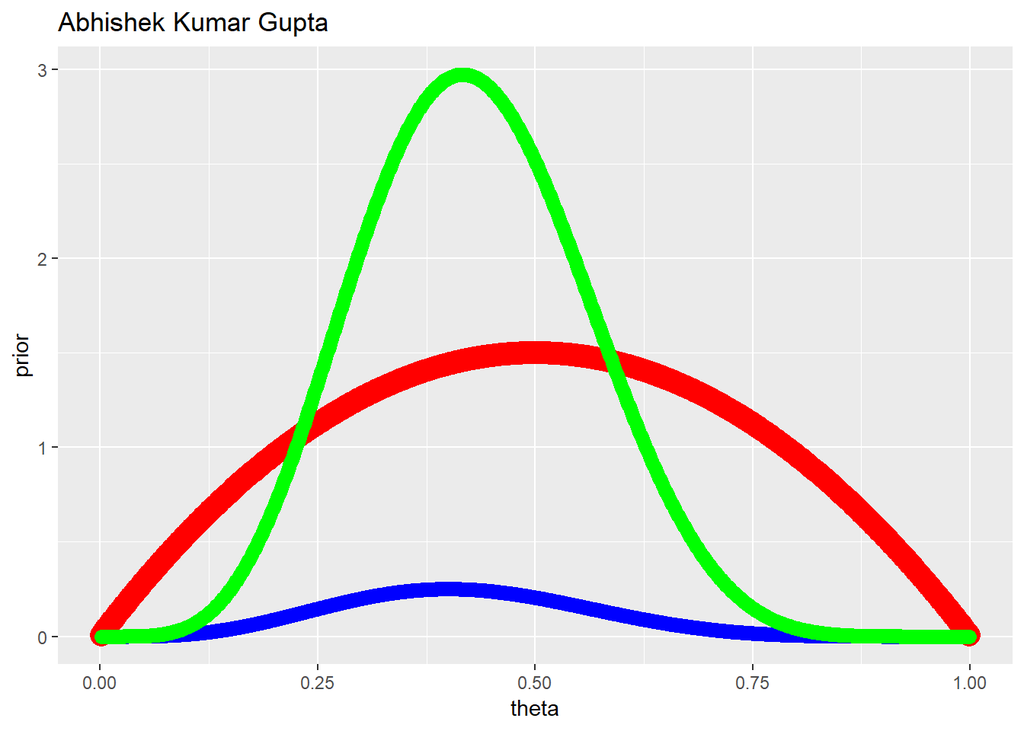

### ii. Mybeta2(alpha = 2, beta=2, n=10, x=4, alphalevel=0.10)

```r
mybeta2(2,2,10,4,0.10)
```

```
## $mean
## [1] 0.5
##
## $mode
## [1] 0.5
##
## $BCI
## [1] 0.1353504 0.8646496
##
## [[4]]
```

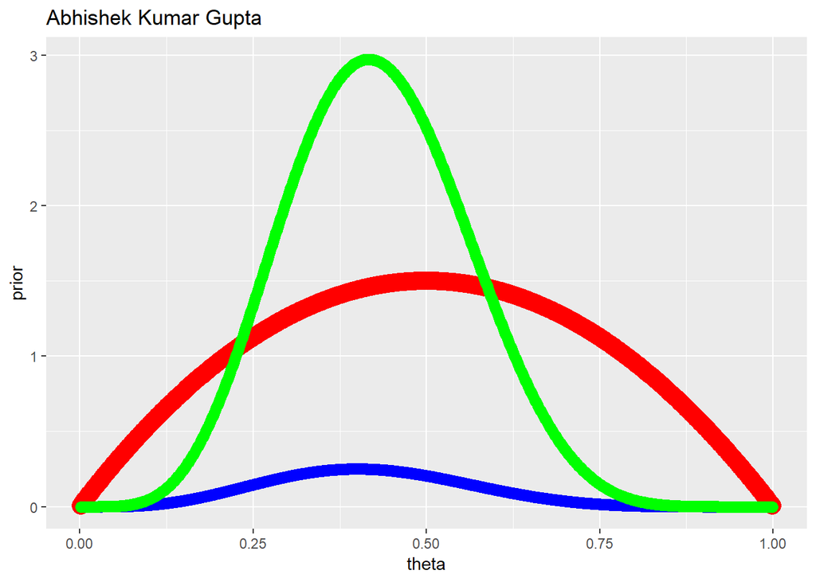

### iii. Mybeta2(alpha = 2, beta=2, n=10, x=3, alphalevel=0.05)

```r
mybeta2(2,2,10,3,0.05)
```

```
## $mean
## [1] 0.5
##
## $mode
## [1] 0.5
##
## $BCI
## [1] 0.09429932 0.90570068
##
## [[4]]
```

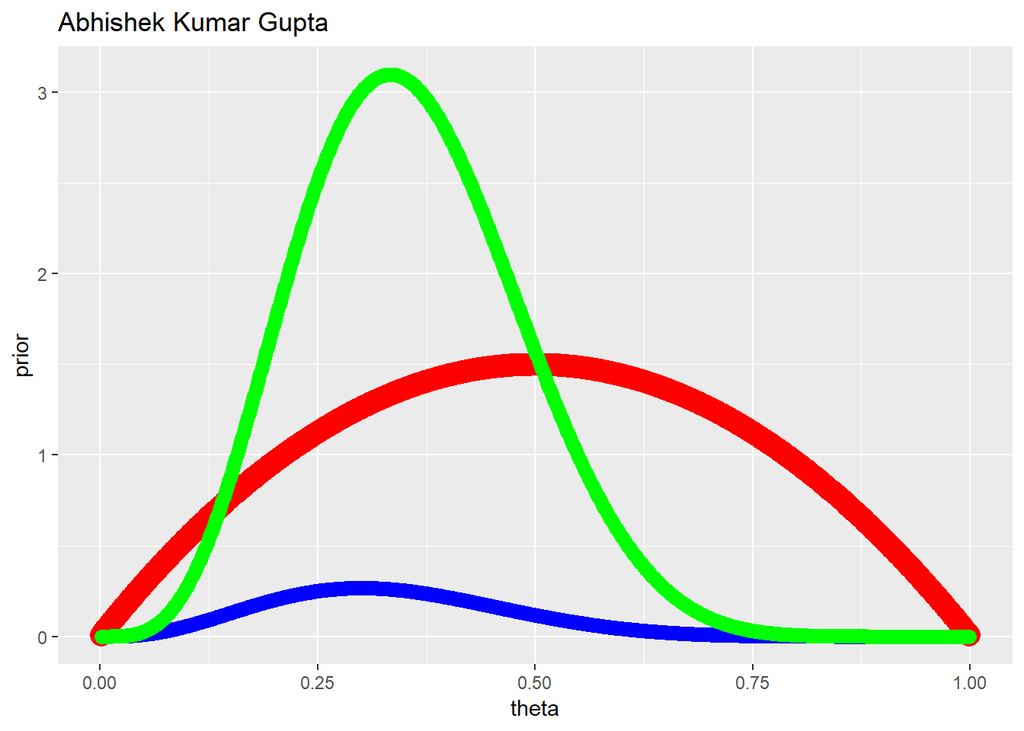

### iv. Mybeta2(alpha = 2, beta=2, n=10, x=3, alphalevel=0.01)

```r
mybeta2(2,2,10,3,0.01)
```

```
## $mean
## [1] 0.5
##
## $mode
## [1] 0.5
##
## $BCI
## [1] 0.04140015 0.95859985
##
## [[4]]
```

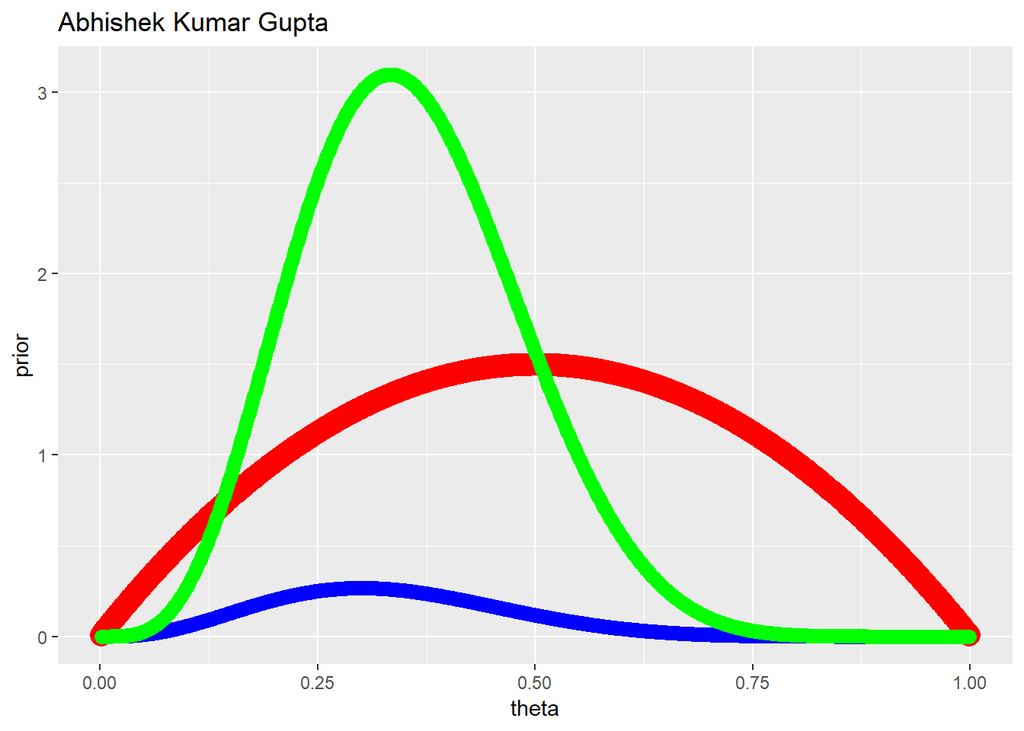

# 2. A prior used to summarize belief about “p” can often be well approximated by a Beta distribution with appropriate choice of hyper-parameters alpha and beta. This will not always be the case. Sometimes a mixture of betas will do a better job. A mixture of beta densities can be expressed in the following way $mixbeta(x) = w*dbeta(x,a1,b1) + (1-w)*dbeta(x,a2,b2)$ where w is a mixing weight and a number between 0 and 1.

## a. Show that mixbeta satisfies the first 2/3 properties of a density. The three properties are:

### i $f(x)>=0$

Since its a probability density function, it must be always positive. Also, beta function will give the positive values

### ii $\int_{-\infty}^{\infty} f(x) dx = 1$

Area under the curve of any probability density function over all the domain values will give 1.

### iii. $p(a<X<b) = \int_{a}^{b} f(x) dx$

## b. Make an R function that will create the mixture density using mixbeta as described above:

```r
mymix = function(w,a1,b1,a2,b2)
{
  w*dbeta(x,a1,b1) + (1-w)*dbeta(x,a2,b2)
}
```

## c. Make a function that will plot the mixture - call it mymixplot(). Show the output when the following are submitted:

```r
mymixplot = function(w,a1,b1,a2,b2)
{
  x= seq(0.001,0.999,by=0.001)
  y<- w*dbeta(x,a1,b1) + (1-w)*dbeta(x,a2,b2)
  plot(y=y,x=x,xlim = c(0,1), ylab = "mixbeta", type = "l", col = "green", lwd = 4, main = "Abhishek")
}
```

### i. Mymixplot(w=0.3, a1=2,b1=4,a2=4,b2=2)

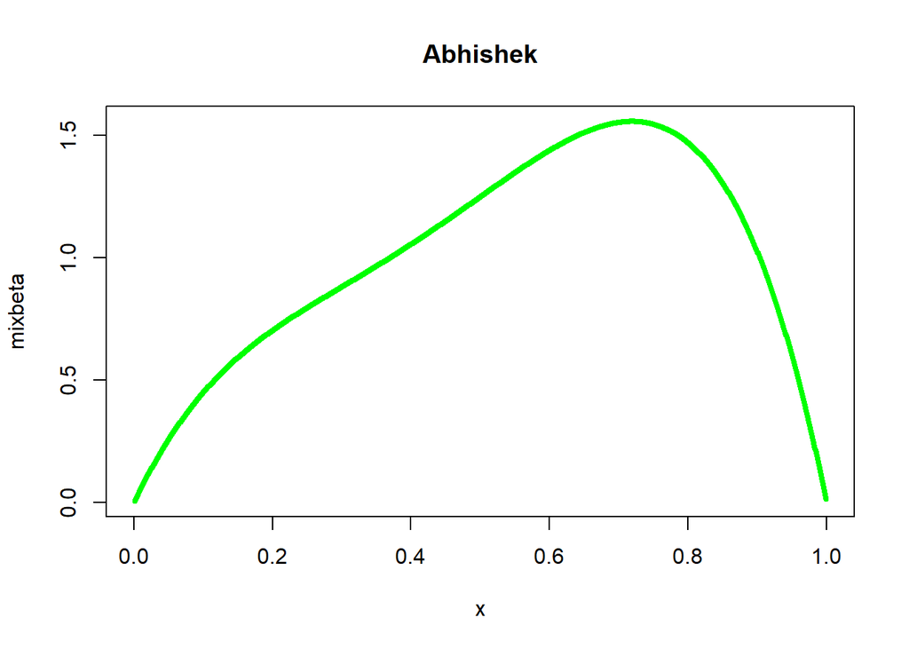

```r
mymixplot(0.3,2,4,4,2)
```

### ii. Mymixplot(w=0.5, a1=2,b1=4,a2=4,b2=2)

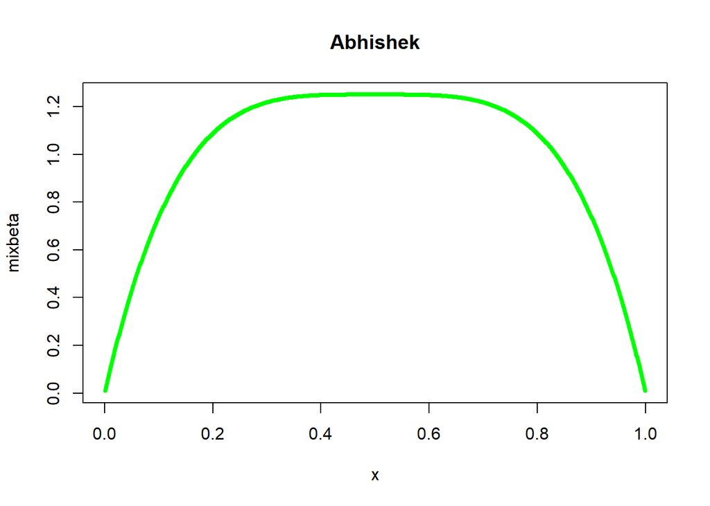

```r
mymixplot(0.5,2,4,4,2)
```

### iii. Mymixplot(w=0.7, a1=2,b1=4,a2=4,b2=2)

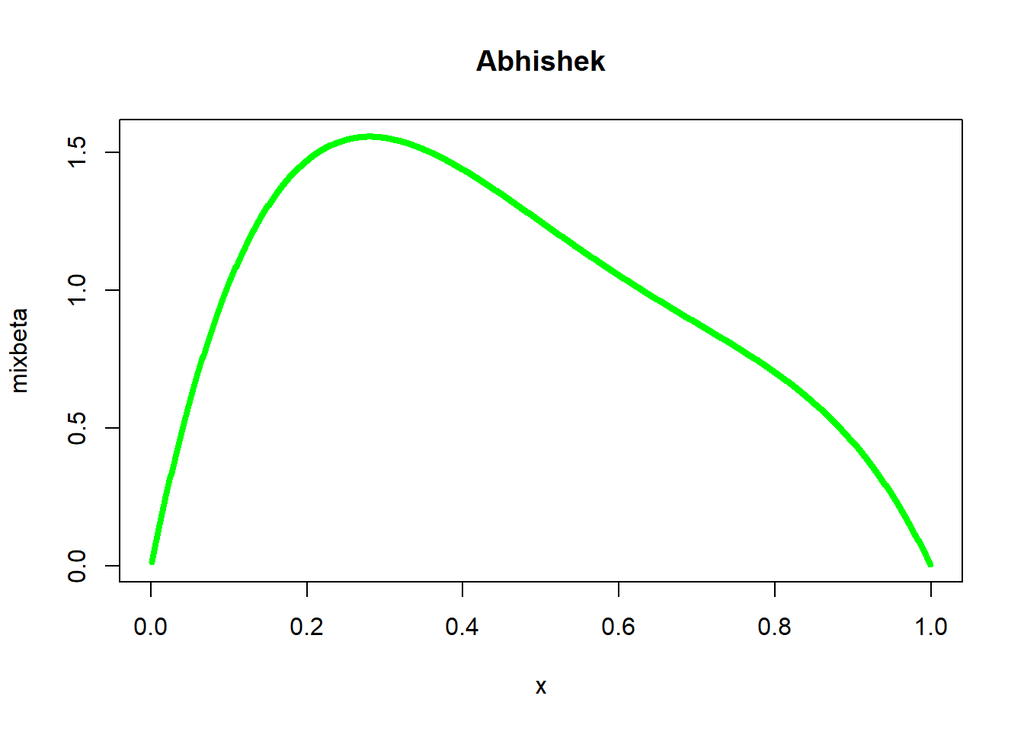

```r
mymixplot(0.7,2,4,4,2)
```

### iv. Mymixplot(w=0.9, a1=2,b1=4,a2=4,b2=2)

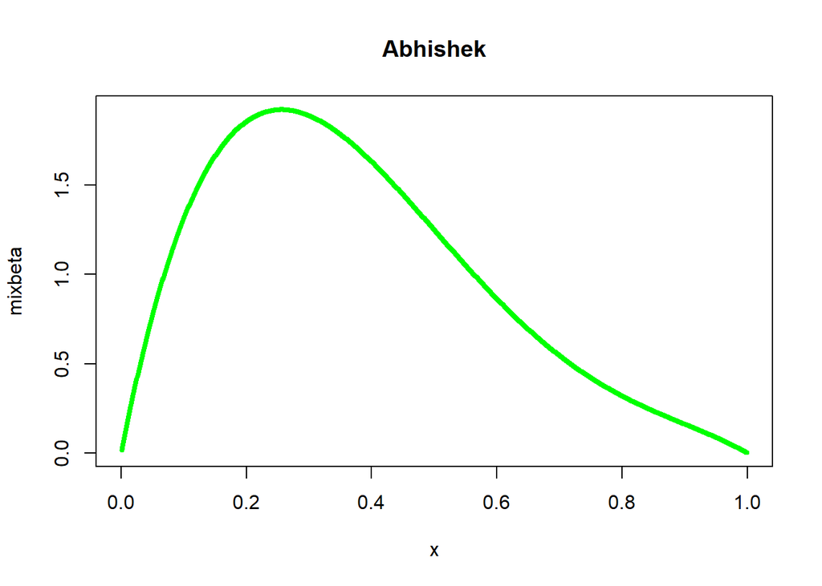

```r
mymixplot(0.9,2,4,4,2)
```

# d. Using the mixbeta prior and a single Binomial (x successes in n trials)

## i. Find the analytical posterior - that is do the algebra and show that the posterior is a mixture also.

So, we have prior as mixbeta

$$mixbeta(x) = w*dbeta(x,a1,b1) + (1-w)*dbeta(x,a2,b2)$$

using the beta expansion, we get

$$prior = (w*\frac{\theta^{\alpha_1-1}*(1-\theta)^{\beta_1-1})}{B(\alpha_1,\beta_1)} + (1-w)*\frac{\theta^{\alpha_2-1}*(1-\theta)^{\beta_2-1})}{B(\alpha_2,\beta_2)})$$
and the likelihood is given as:
$$likelihood = {n\choose x}\theta^{x} (1-\theta)^{n-x}$$
Since,
$$Posterior \propto prior*likelihood$$

$$MixPosterior \propto (w*\frac{\theta^{\alpha_1-1}*(1-\theta)^{\beta_1-1})}{B(\alpha_1,\beta_1)} + (1-w)*\frac{\theta^{\alpha_2-1}*(1-\theta)^{\beta_2-1})}{B(\alpha_2,\beta_2)}) * {n\choose x}\theta^{x} (1-\theta)^{n-x}$$
Remoivng the proportionality and putting equality, we get
$$MixPosterior = (w*\frac{\theta^{\alpha_1-1}*(1-\theta)^{\beta_1-1})}{B(\alpha_1,\beta_1)} + (1-w)*\frac{\theta^{\alpha_2-1}*(1-\theta)^{\beta_2-1})}{B(\alpha_2,\beta_2)}) * \frac {{n\choose x}\theta^{x} (1-\theta)^{n-x}} {p(x,n)}$$

Multplying the terms,

$$MixPosterior = (w*\frac{\theta^{\alpha_1-1}*(1-\theta)^{\beta_1-1})}{B(\alpha_1,\beta_1)}*\frac {{n\choose x}\theta^{x} (1-\theta)^{n-x}} {p(x,n)}+ ((1-w)*\frac{\theta^{\alpha_2-1}*(1-\theta)^{\beta_2-1})}{B(\alpha_2,\beta_2)}) * \frac {{n\choose x}\theta^{x} (1-\theta)^{n-x}} {p(x,n)})$$

After rearranging the terms and collecting powers, we get

$$MixPosterior = \frac {w*{n\choose x}*{\theta^{\alpha_1+x-1}*(1-\theta)^{n-x+\beta_1-1}}} {p(x,n)*B(\alpha_1,\beta_1)}+ \frac {(1-w)*{n\choose x}*{\theta^{\alpha_2+x-1}*(1-\theta)^{n-x+\beta_2-1}}} {p(x,n)*B(\alpha_2,\beta_2)}$$
Since ${n\choose x}$ is constant like the bottom terms, we can write together as a function of constant terms as:

$$MixPosterior = \frac {w*{\theta^{\alpha_1+x-1}*(1-\theta)^{n-x+\beta_1-1}}} {B(\alpha_1+x,\beta_1+n-x)}+ \frac {(1-w)*{\theta^{\alpha_2+x-1}*(1-\theta)^{n-x+\beta_2-1}}} {B(\alpha_2+x,\beta_2+n-x)}$$
Here, we see that posterior is also a beta distribution whihc can be written as:

$$MixPosterior = w*dbeta(\alpha_1+x,\beta_1+n-x)+(1-w)*dbeta(\alpha_2+x, \beta_2+n-x)$$
Therefore, we see that posterior is also a beta mixture.

## ii. What is the posterior mixing weight?

Let the two prior distribution given above as $P_1 and P_2 $ with mixture weight w So, mixture distribution $P(\theta)$ can be given as:
$$P(\theta) = w* P_1(\theta) + (1-w)*P_2(\theta)$$
After observing the data y, posterior will be given as:

$$P(\theta|y) = w'* P_1(\theta|y) + (1-w')*P_2(\theta|y)$$
where W’ is the posterior mix weight. since, by Bay’s rule we have

$$p_i(\theta|y) \propto p(y_i|\theta)p_i(\theta)$$
So, posterior mix weight can be calculated as :
$$w' = \frac{wp_1(y)}{wp_1(y)+wp_2(y)}$$
where
$$p_i(y) = \int p(y|\theta) p_i(\theta)d\theta$$

## iii. Plot the prior, likelihood and posterior on the same set of axes when w = 0.5, n=10, x =4, a1 =a2=2,b1=b2=4

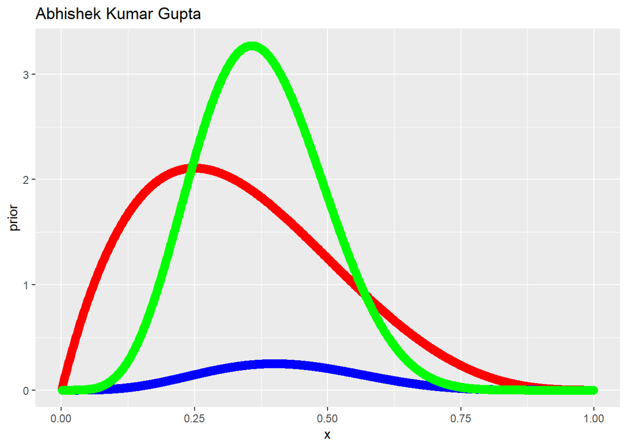

```r
mymix = function(w,a1,b1,a2,b2)
{
  w*dbeta(x,a1,b1) + (1-w)*dbeta(x,a2,b2)
}

mymix_post = function(w,a1,b1,a2,b2,n,p)
{
  w*dbeta(x,a1+p,n-p+b1) + (1-w)*dbeta(x,a2+p,n-p+b2)
}

x = seq(0.001,0.999,by=0.001) # points for plotting
prior= mymix(0.5,2,4,2,4)
lik= dbinom(x=4,size = 10, x) # likelihood for plotting
post = mymix_post(0.5,2,4,2,4,10,4) # posterior for plotting
df = data.frame(x, prior, lik, post)
library(ggplot2)
myplot = ggplot(df, aes(x)) + geom_point(aes(y=prior), col = "red", size = 3) +
  geom_point(aes(y=lik), col = "blue", size =3) +geom_point(aes(y=post), col ="green", size =3) +
  labs(title = "Abhishek Kumar Gupta")
myplot
```

# 3. The following problem relates to the above notions of mixtures. Suppose a coin is either “unbiased” or “biased”. In which case the chance of a “head” is unknown and is given a uniform prior distribution. We assess a prior probability of 0.9 that it is “unbiased”, and then observe 15 heads out of 20 tosses.

## a. Explain how the JAGS distribution function dcat() works.

The dcat() function will produce the index (1 or 2) based on whats inside it. In our case, it will produce either 1 or 2 based on the proabbility q[1] and q[2].

## b. Take the above model and use it within JK’s code “Jags-ExampleScript.R” adjusting it so that it will create an MCMC sample from the posterior. The two parameters you must monitor are “theta[2]” and “biased” (note: you do not need the inits function - just use something like: initsList = list( pick = 1)) - do NOT attempt to plot the “biased” parameter yet - ONLY “theta[2]”.

## c. Once you have it working place the script within the body of a function - say mypriormix(), you can then call the script by simply calling the function (no options are needed).

## Ans: 3b,c

```r
   # Jags-ExampleScript.R
  # Optional generic preliminaries:
  #graphics.off() # This closes all of R's graphics windows.
  #rm(list=ls())  # Careful! This clears all of R's memory!

  # Load the functions used below:
  source("DBDA2E-utilities.R") # Must be in R's current working directory.
```

```
##
## Kruschke, J. K. (2015). Doing Bayesian Data Analysis, Second Edition:
## A Tutorial with R, JAGS, and Stan. Academic Press / Elsevier.
```

```
## Linked to JAGS 4.3.0
```

```
## Loaded modules: basemod,bugs
```

```r
  require(rjags)               # Must have previously installed package rjags.

  fileNameRoot="Jags-Assignment2" # For output file names.

  modelString = "
  model {
  x ~ dbin( p, n )
  p <- theta[pick]
  pick ~ dcat(q[]) # categorical 1 produced prob q[1], etc
  # pick is 2 if biased 1 unbiased
  q[1]<-0.9
  q[2]<-0.1
  theta[1] <-0.5 # unbiased
  theta[2] ~ dunif(0,1) # biased
  biased <- pick - 1
  }
  " # close quote for modelString

  writeLines( modelString , con="TEMPmodel.txt" )

  data.List = list( x = 15, n=20)
  initsList = list(pick=1)

  # Run the chains:
  jagsModel = jags.model( file="TEMPmodel.txt" , data=data.List , inits=initsList ,
                          n.chains=3 , n.adapt=500 )
  update( jagsModel , n.iter=500 )
  codaSamples = coda.samples( jagsModel , variable.names=c("theta[1]","biased","theta[2]") ,
                              n.iter=3334 )
  save( codaSamples , file=paste0(fileNameRoot,"Mcmc.Rdata") )
```

## d. Show the MCMC diagnostics and the posterior sample histograms for theta[2].

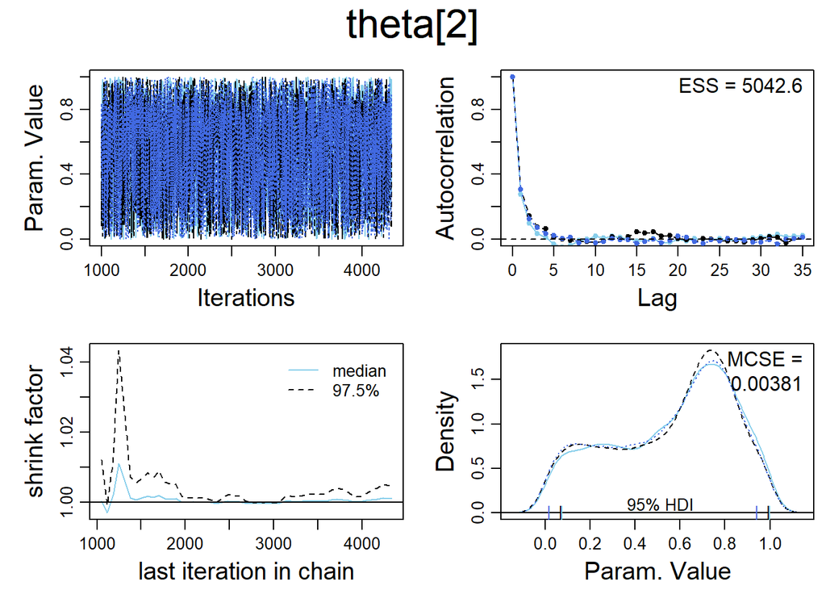

```r
 # Examine the chains:
  # Convergence diagnostics:
  diagMCMC( codaObject=codaSamples , parName="theta[2]" )
  saveGraph( file=paste0(fileNameRoot,"ThetaDiag") , type="eps" )
```

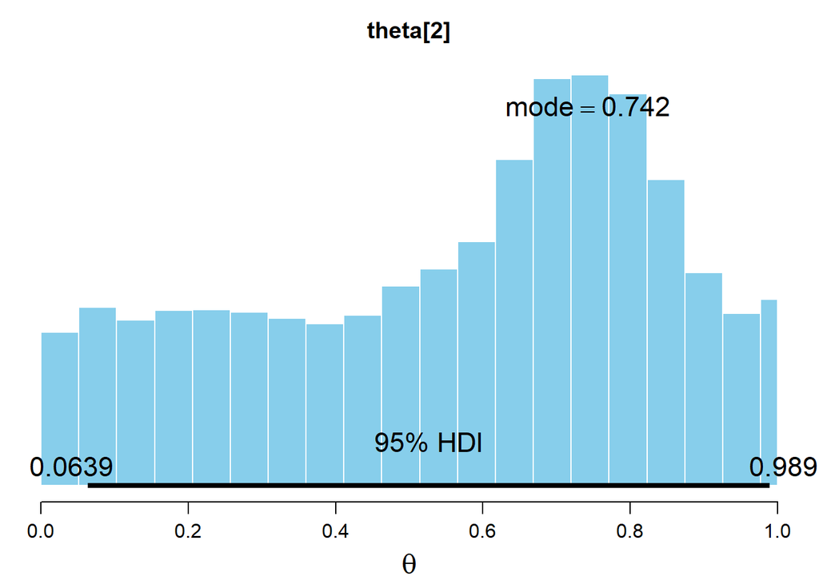

```
##            ESS      mean    median      mode hdiMass     hdiLow  hdiHigh
## theta 5042.091 0.5609819 0.6292519 0.7421701    0.95 0.06391334 0.989331
##       compVal pGtCompVal ROPElow ROPEhigh pLtROPE pInROPE pGtROPE
## theta      NA         NA      NA       NA      NA      NA      NA
```

```r
  # Posterior descriptives:
  openGraph(height=3,width=4)
  par( mar=c(3.5,0.5,2.5,0.5) , mgp=c(2.25,0.7,0) )
  plotPost( codaSamples[,"theta[2]"] , main="theta[2]" , xlab=bquote(theta) )
```

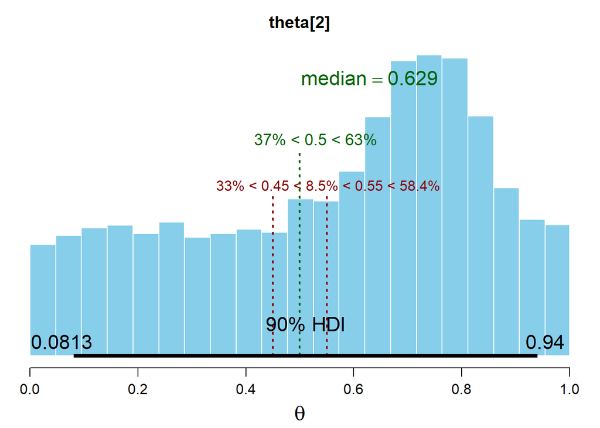

```
##            ESS      mean    median      mode hdiMass     hdiLow  hdiHigh
## theta 5042.091 0.5609819 0.6292519 0.7421701     0.9 0.08129227 0.940296
##       compVal pGtCompVal ROPElow ROPEhigh  pLtROPE    pInROPE   pGtROPE
## theta     0.5  0.6295741    0.45     0.55 0.330234 0.08528294 0.5844831
```

```r
  saveGraph( file=paste0(fileNameRoot,"ThetaPost") , type="eps" )
  # Re-plot with different annotations:
  plotPost( codaSamples[,"theta[2]"] , main="theta[2]" , xlab=bquote(theta) ,
            cenTend="median" , compVal=0.5 , ROPE=c(0.45,0.55) , credMass=0.90 )
```

```r
  saveGraph( file=paste0(fileNameRoot,"ThetaPost2") , type="eps" )
```

## e. Show the summary information of the posterior sample - what is the sample called in the script? Hint: Use summary(); su = summary(.); su$statistics

The sample is called codasamples in the script.

```r
su=summary(codaSamples)
su$statistics
```

```
##               Mean        SD    Naive SE Time-series SE
## biased   0.2617477 0.4396079 0.004395640    0.006236405
## theta[1] 0.5000000 0.0000000 0.000000000    0.000000000
## theta[2] 0.5609819 0.2703900 0.002703629    0.003855440
```

## f. What is the posterior probability that the coin is biased?

From the above statistics, we see that posterior probability that the coin is biased is now ~ 26%

# 4. We will work on the same model as in question 3. This time we will examine the model in light of the theory covered in section 10.3.2.1 page 279 and following. The first thing we will need to do is manipulate the list of data created by the JAGS sampler. Locate the mcmc data which will be in the form of a list.

## a. Give the structure of the MCMC data in the file produced by the jags script you made in qu. 3 hint: str(.)

```r
str(codaSamples)
```

```
## List of 3
##  $ : 'mcmc' num [1:3334, 1:3] 1 0 0 0 0 0 0 0 0 0 ...
##   ..- attr(*, "dimnames")=List of 2
##   .. ..$ : NULL
##   .. ..$ : chr [1:3] "biased" "theta[1]" "theta[2]"
##   ..- attr(*, "mcpar")= num [1:3] 1001 4334 1
##  $ : 'mcmc' num [1:3334, 1:3] 0 0 0 0 0 0 0 0 1 1 ...
##   ..- attr(*, "dimnames")=List of 2
##   .. ..$ : NULL
##   .. ..$ : chr [1:3] "biased" "theta[1]" "theta[2]"
##   ..- attr(*, "mcpar")= num [1:3] 1001 4334 1
##  $ : 'mcmc' num [1:3334, 1:3] 0 0 0 0 0 0 0 0 1 0 ...
##   ..- attr(*, "dimnames")=List of 2
##   .. ..$ : NULL
##   .. ..$ : chr [1:3] "biased" "theta[1]" "theta[2]"
##   ..- attr(*, "mcpar")= num [1:3] 1001 4334 1
##  - attr(*, "class")= chr "mcmc.list"
```

## b. Use the following code to make mcmcT by filling in the correct object name

```r
mcmc1 = as.data.frame(codaSamples[[1]])
mcmc2 = as.data.frame(codaSamples[[2]])
mcmc3 = as.data.frame(codaSamples[[3]])
mcmcT = rbind.data.frame(mcmc1,mcmc2,mcmc3)
```

## c. Using mcmcT and the ggplot2 R package make the following plot after first understanding precisely the pseudo prior method. Make sure you have YOUR name on it!! Colors don’t have to precisely correspond.

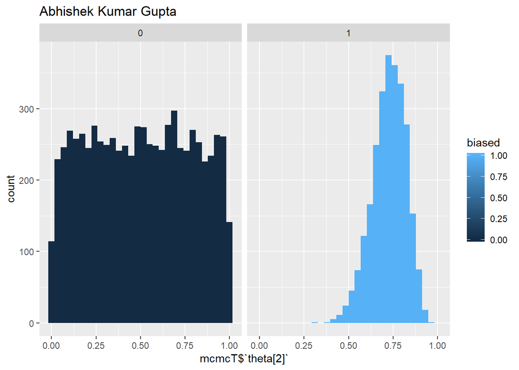

```r
t<- ggplot(data = mcmcT, aes(mcmcT$`theta[2]`,fill = biased)) +geom_histogram(stat = "bin")
t+facet_wrap(~biased)+ labs(title = "Abhishek Kumar Gupta")
```

# d. Looking at the picture above and considering the model, answer the following:

## i. When the parameter biased = 0:pick = ?,

pick = 1

## ii. when biased = 1: pick = ?

pick = 2

# e. The three variables updated in the Gibbs sampler will go in alphabetical order pick, theta[1] and then theta[2] and then cycling around again and again . .

## i. When pick = 1, theta[1] will be sampled from the posterior, then theta[2] will be sampled from what?

Prior

## ii. When pick = 2 what will theta[1] be sampled from?

Prior

## iii. When pick = 2 what will theta[2] be sampled from?

Posterior

## iv. Now explain the plot in d) from the above.

This plot explains the observaed answers in parts i,ii,iii i.e, when pick =1 we have biased equals 0 which corresponds to the left plot. This indicates that, when biased=0 theta[1] is sampled from posterior and theta[2] is sampled from prior as can be seen from the uniform prior in the plot

SImilarly, when pick is 2, we have biased 1 which means the right plot. Form this, we see that when pick=2, theta[2] is sampled from posterior as can be seen from the non-uniform distribution and theta[1] will be sampled form the prior.

## v. Which plot (dark or light) blue would likely represent the true underlying posterior of theta[2]

Light blue

## vi. Now create the following plot which represents the incorrect posterior of theta[2] using ggplot - make sure your name is on it.

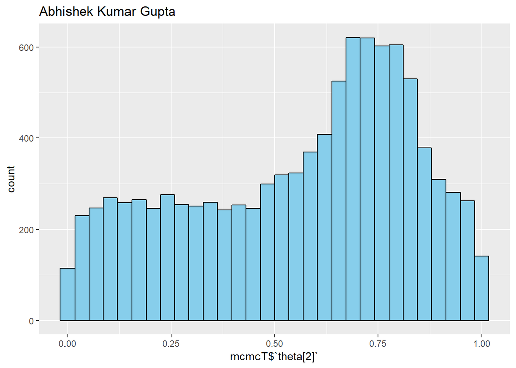

```r
ggplot(data = mcmcT, aes(mcmcT$`theta[2]`))+geom_histogram(stat = "bin", col="black", fill = "skyblue")+ labs(title = "Abhishek Kumar Gupta")
```

## vii. Explain the above plot - why does it have the shape it has and then say why it cannot be a true representation of the posterior for theta[2]?